# Introduction to Data Visualization with Seaborn

## Introduction to Seaborn

- Easy to use
- Works well with pandas data structures
- Built on top of matplotlib

```python
import seaborn as sns
import matplotlib.pyplot as plt
import numpy as np
import pandas as pd
```

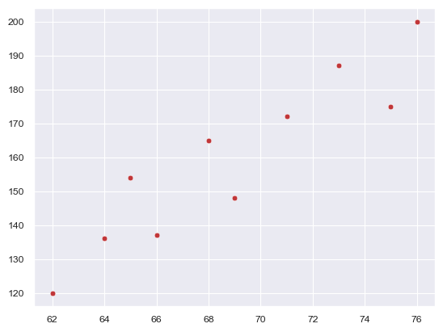

```python
height = [62, 64, 69, 75, 66, 68, 65, 71, 76, 73]
weight = [120, 136, 148, 175, 137, 165, 154, 172, 200, 187]

#!Notice that we have to specify x and y
sns.scatterplot(x=height, y=weight)
plt.figure(figsize=(4,3))
plt.show()
```

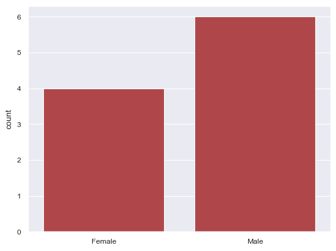

```python
gender = ["Female", "Female", "Female", "Female",
           "Male", "Male", "Male", "Male", "Male", "Male"]

sns.countplot(x=gender)
plt.show()
```

## Adding a third variable with hue

there is a special dataset tips which is included in seaborn by default

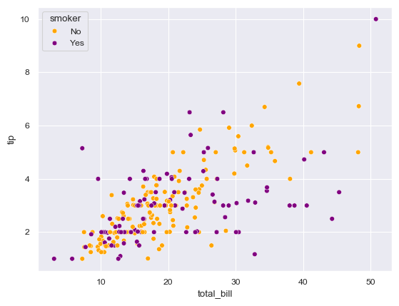

```python
tips = sns.load_dataset("tips")

hue_colors = {"Yes": "purple",
              "No": "orange"}

sns.scatterplot(x="total_bill", y="tip", data=tips,
                 hue="smoker", hue_order=["No", "Yes"],
                 palette = hue_colors)
plt.show()
```

## Introduction to relational plots and subplots

Relational plots `relplot`:

- lineplot
- scatterplot

We use relplot cause it allows us to create subplots in a single figure

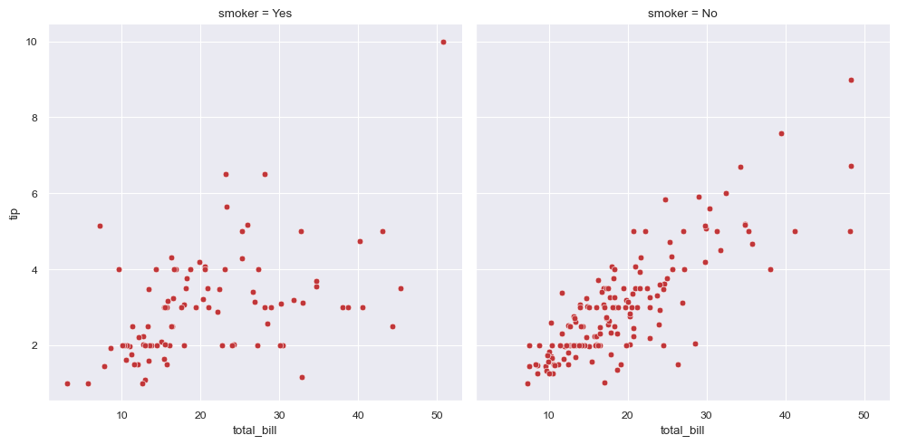

```python
sns.relplot(x="total_bill",
            y="tip",
            data=tips,
            kind="scatter",
            col="smoker" #could have used row
            )

plt.show()
```

If you have too many values (like several dayes of the week you can use `col_wrap` to wrap it into 2 lines instead of 1 and the use`col_order` to specify the order)

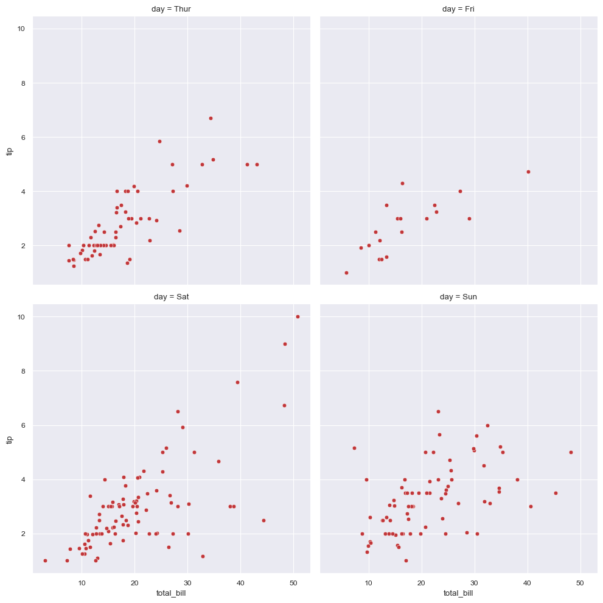

```python
sns.relplot(x="total_bill",
            y="tip",
            data=tips,
            kind="scatter",
            col="day", #could have used row
            col_wrap=2,
            col_order=["Thur",
                       "Fri",
                       "Sat",
                       "Sun"])

plt.show()
```

## Customizing scatter plots

size and hue

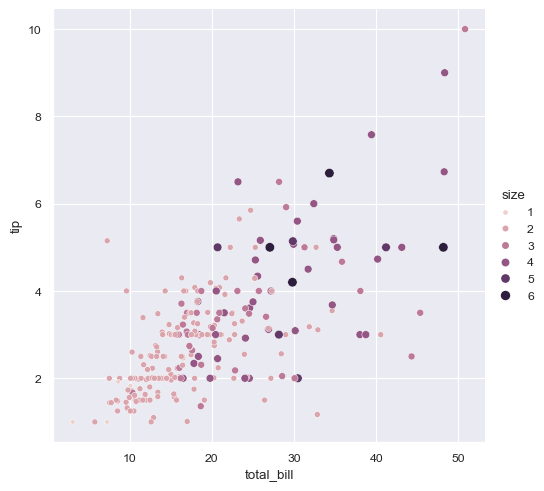

```python
sns.relplot(x="total_bill",
            y="tip",
            data=tips,
            kind="scatter",
            size="size",
            hue="size"
)

plt.show()
```

style

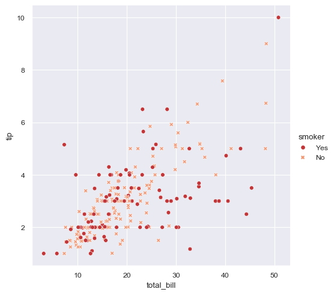

```python
sns.relplot(x="total_bill",
            y="tip",
            data=tips,
            kind="scatter",
            hue="smoker",
            style="smoker"
)

plt.show()
```

alpha

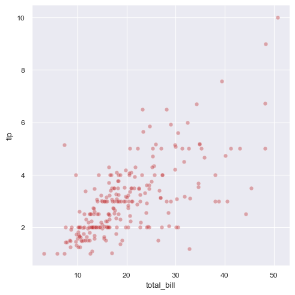

```python
sns.relplot(x="total_bill",
            y="tip",
            data=tips,
            kind="scatter",
            alpha=0.4
)

plt.show()
```

## Introduction to line plots

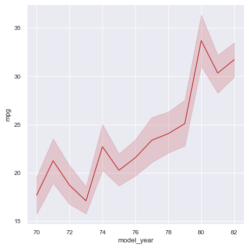

```python
mpg = pd.read_csv("databases/mpg.csv")

sns.relplot(x="model_year", y="mpg",
            data=mpg, kind="line")
plt.show()
```

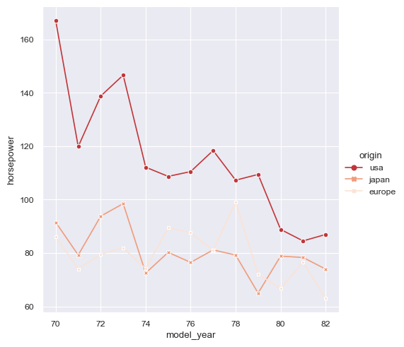

```python
sns.relplot(x="model_year", y="horsepower",
            data=mpg,
            kind="line",
            errorbar=None,
            style="origin",
            hue="origin",
            markers=True,
            dashes=False)
plt.show()
```